# Logistic regression

Mats Hansson

16 april 2016

## How to bulid a logistic regression

First we have to create some data, the simulated data is normal distributed with a mean at 1 and a variance is 1. The other simulated data is also normal distributed with a mean at 4 and the variance is 1.

```r
#Predictor variables
set.seed(1)
X <- cbind(1,c(rnorm(100, 1, 1), rnorm(100,4,1)))


#Response variable
Y <- matrix(data=c(rep(0,100), rep(1,100)))
```

### Plot the data

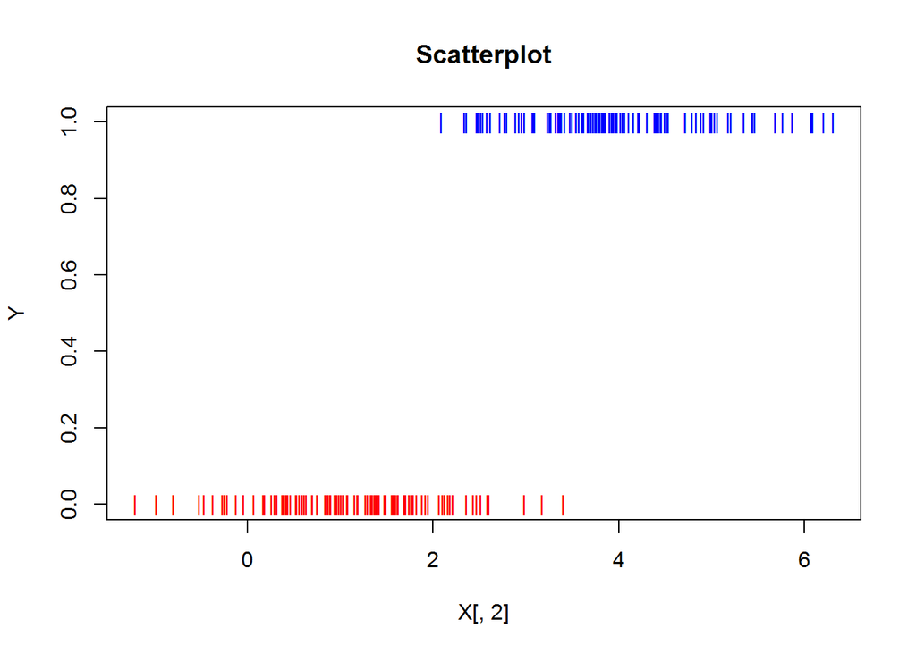

```r
color=c(rep("red", 100),rep("blue", 100))
plot(X[,2],Y, pch='|', col=color, main = "Scatterplot")
```

Where function g is the sigmoid function. The sigmoid function is defined as: $g(y) = \frac{1}{1+e^{-z}}.$

Our first step is to implement sigmoid function.

```r
#Sigmoid function
sigmoid <- function(z)
{
  g <- 1/(1+exp(-z))
  return(g)
}
```

Now we will implement cost function.

```r
#Cost Function
cost <- function(theta)
{
  m <- nrow(X)
  g <- sigmoid(X%*%theta)
  J <- (1/m)*sum((-Y*log(g)) - ((1-Y)*log(1-g)))
  return(J)
}
```

Let’s test this cost function with initial theta parameters. We will set theta parameters equal to zero initially and check the cost.

```r
#Intial theta
initial_theta <- rep(0,ncol(X))

# initalize theta vector
theta<- c(0,0)

# Number of the observations
m <- nrow(X)


#Cost at inital theta
cost(initial_theta)
```

```
## [1] 0.6931472
```

You will find cost is 0.693 with initial parameters. Now, our objective is to minimize this cost and derive the optimal value of the thetas.

Here I will use inbuilt function of R `optim()` to derive the best fitting parameters. Ultimately we want to have optimal value of the cost function and theta.

```r
# Derive theta using gradient descent using optim function
theta_optim <- optim(par=initial_theta,fn=cost)
```

The cofficeint in the model is:

```r
#set beta
coef <- theta_optim$par
print(coef)
```

```
## [1] -10.253795   4.066617
```

```r
#cost at optimal value of the theta
theta_optim$value
```

```
## [1] 0.1260329
```

We know that the red observation chould have a mean at 1 and the blue at 4 therefore the best split is (4-1)/2+1 =2.5

the simulated mean is for the red observation is

```r
mean(X[1:100,2])
```

```
## [1] 1.108887
```

and for the blue is

```r
mean(X[101:200,2])
```

```
## [1] 3.962192
```

If I use the probability, than we can plot the probability curve:

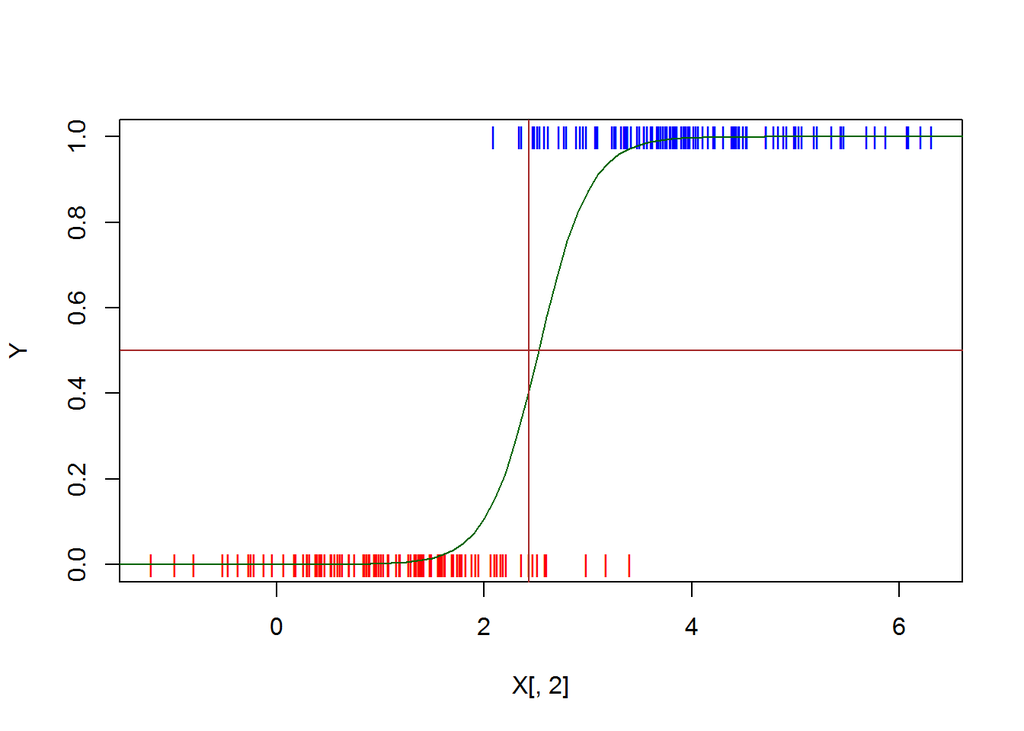

```r
### plot ###
color=c(rep("red", 100),rep("blue", 100))
plot(X[,2],Y, pch='|', col=color)

### prediction  ###
xmat=cbind(1, seq(-3, 7, by=0.1))

### the  odds prediction ###
pred_odds<-xmat%*%coef

### The prediction ###
pred=exp(pred_odds)/(1+exp(pred_odds))


### The prediction line ###
lines(xmat[,2], pred, col="darkgreen")

## the vertical line is
abline(v=(mean(X[101:200,2])-mean(X[1:100,2]))/2+1, col="brown")

## The horizontial line is
abline(h=0.5, col="brown")
```